# Bayesian modeling and prediction for movies

## Setup

### Load packages

```r
library(ggplot2)
library(dplyr)
library(statsr)
library(BAS)
#multiple graphs on one picture
library(gridExtra)
```

### Load data

```r
load("movies.Rdata")
```

## Part 1: Data

The dataset consists of 651 movies released before 2016, which were randomly sampled from web sites rottentomatoes.com and IMDB.com.

Since random sampling was used and sample size is less than 10% of all movies released before 2016 we can generalize the model to all movies publicly released for english speaking viewers. At the same time we can only imply association, since it was not an experiment and study is observational.

The only source of bias is that both websites are centered around english speaking viewers. Which limits our model applications. For example we would need another dataset to create a model for movies released in other languages.

## Part 2: Data manipulation

First of all as project information suggests we need to create new columns in the “movies” data frame. All new columns are 2 level vectors with values “yes” and “no”. Names of the columns are the following: feature_film, drama, mpaa_rating_R, oscar_season and summer_season.

```r
movies <- movies %>% mutate(
  feature_film = as.factor(if_else(title_type == 'Feature Film', 'yes', 'no')),
  drama = as.factor(if_else(genre == 'Drama', 'yes', 'no')),
  mpaa_rating_R = as.factor(if_else(mpaa_rating == 'R', 'yes', 'no')),
  oscar_season = as.factor(if_else((thtr_rel_month == 10 | thtr_rel_month == 11 |
                                      thtr_rel_month == 12), 'yes', 'no')),
  summer_season = as.factor(if_else((thtr_rel_month == 5 |
                                       thtr_rel_month == 6 |
                                       thtr_rel_month == 7 |
                                       thtr_rel_month == 8), 'yes', 'no')))
```

## Part 3: Exploratory data analysis

`audience score` is the response variable we are interested in. It show how audience from Rotten Tomatoes website rated a movie. First let’s examine the distribution of the variable.

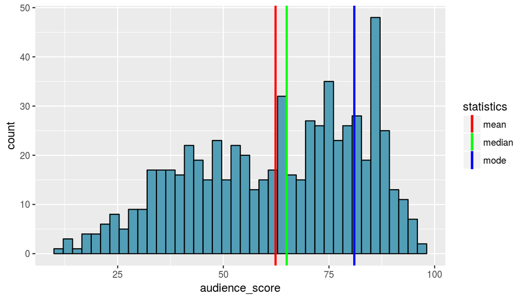

```r
#creating the mode function
Mode <- function(x) {
  ux <- unique(x)
  ux[which.max(tabulate(match(x, ux)))]
}
#plotting
ggplot(movies, aes(x = audience_score)) +
  geom_histogram(color = 'black', fill='#529eb7', bins = 40)+
  geom_vline(mapping = aes(xintercept = mean(audience_score), color = 'mean'),
             size = 1) +
  geom_vline(mapping = aes(xintercept = median(audience_score),
                           color = 'median'), size = 1) +
  geom_vline(mapping = aes(xintercept = Mode(audience_score),color = 'mode'),
             size = 1)+
  scale_color_manual(name = "statistics",
                    values = c(median = "green", mean = "red", mode = "blue"))
```

```r
#numeric values
summary(movies$audience_score)
```

```
##    Min. 1st Qu.  Median    Mean 3rd Qu.    Max.
##   11.00   46.00   65.00   62.36   80.00   97.00
```

```r
sprintf("Mode is equal to %i", Mode(movies$audience_score))
```

```
## [1] "Mode is equal to 81"
```

Figure 1. We can see that distribution of `audience_score` variable is left skewed. This is because we can see left tail and also because mean is smaller than median and mode.

Now let’s examine if variables which we just created differ.

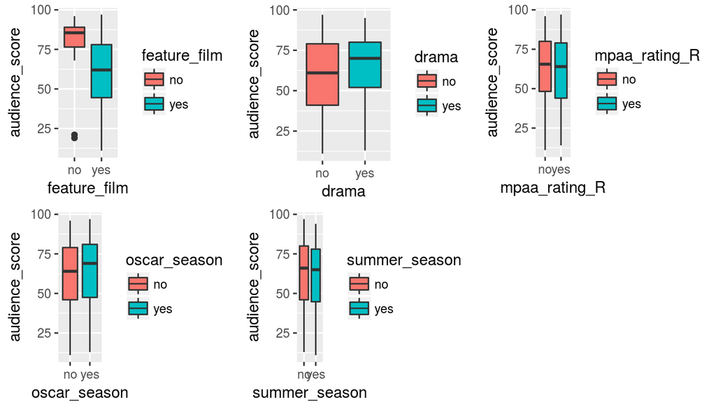

```r
#wrap boxplot into a function
create_boxplot <- function(data, x, y) {
  ggplot(data, aes_string(x = x, y = y, fill = x)) +
    geom_boxplot()
}
#create individual plots
p1 = create_boxplot(movies, "feature_film", "audience_score")
p2 = create_boxplot(movies, "drama", "audience_score")
p3 = create_boxplot(movies, "mpaa_rating_R", "audience_score")
p4 = create_boxplot(movies, "oscar_season", "audience_score")
p5 = create_boxplot(movies, "summer_season", "audience_score")
#plot
grid.arrange(p1,p2,p3,p4,p5, nrow = 2)
```

Figure 2. We can see that in all cases there is a slight difference between “yes” and “no” answers. Documentaries have higher scores than feature films. Drama movies have higher scores than others. Finally movies released during the Oscar season score higher on average than movies released at other time. In case with MPAA rating variable and summer season variable difference is quite small.

Now let’s check if we can confirm the finding above statistically. I will use *bayes_inference* function from `statsr` package to check if newly created variables affect the `audience_score` variable. Unfortunately one sided hypothesis testing is not currently supported.

```r
ff = bayes_inference(y = audience_score, x = feature_film, data = movies, statistic = "mean", type = "ht", null = 0, alternative = "twosided", show_summ = FALSE, show_res = FALSE, show_plot = FALSE)
drama = bayes_inference(y = audience_score, x = drama, data = movies, statistic = "mean", type = "ht", null = 0, alternative = "twosided", show_summ = FALSE, show_res = FALSE, show_plot = FALSE)
mpaa = bayes_inference(y = audience_score, x = mpaa_rating_R, data = movies, statistic = "mean", type = "ht", null = 0, alternative = "twosided", show_summ = FALSE, show_res = FALSE, show_plot = FALSE)
oscar_s = bayes_inference(y = audience_score, x = oscar_season, data = movies, statistic = "mean", type = "ht", null = 0, alternative = "twosided", show_summ = FALSE, show_res = FALSE, show_plot = FALSE)
summer_s = bayes_inference(y = audience_score, x = summer_season, data = movies, statistic = "mean", type = "ht", null = 0, alternative = "twosided", show_summ = FALSE, show_res = FALSE, show_plot = FALSE)

#dataframe for BF
bf = data.frame(
  order = c(ff$order, drama$order, mpaa$order, oscar_s$order, summer_s$order), Bayesian_Factor = c(ff$BF, drama$BF, mpaa$BF, oscar_s$BF, summer_s$BF),
  Post_prob = c(ff$post_H2, drama$post_H2, mpaa$post_H2, oscar_s$post_H2, summer_s$post_H2))
rownames(bf) = c("Factor_film", "Drama", "mpaa_rating_R", "Oscar_season", "Summer_season")
bf
```

```
##               order Bayesian_Factor  Post_prob
## Factor_film   H2:H1    4.221452e+13 1.00000000
## Drama         H2:H1    2.265667e+01 0.95772863
## mpaa_rating_R H1:H2    2.396791e+01 0.04005140
## Oscar_season  H1:H2    1.339926e+01 0.06944801
## Summer_season H1:H2    2.171182e+01 0.04402993
```

I believe that variables `mpaa_rating_R`, `oscar_season` and `summer_season` will be eliminated during modeling process.

## Part 4: Modeling

First let’s subset our dataset down to the variables of interest and remove NA’s.

```r
columns <- c( 'audience_score', 'feature_film', 'drama', 'runtime', 'mpaa_rating_R', 'thtr_rel_year', 'oscar_season', 'summer_season', 'imdb_rating', 'imdb_num_votes', 'critics_score', 'best_pic_nom', 'best_pic_win', 'best_actor_win', 'best_actress_win', 'best_dir_win', 'top200_box')
#remove NAs
movies <- na.omit(movies)
#subsetting
movies <- movies[,columns]
#checking dimensions
dim(movies)
```

```
## [1] 619  17
```

After omiting NA values we have 619 complete cases with 17 variables.

### Now let’s figure out what parameters to use to build the model.

We will start with the full model. I will use Markov Chain Monte Carlo method for sampling models during fitting.

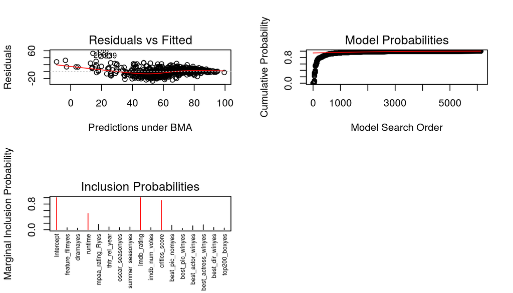

```r
movies_bayesian <- bas.lm(audience_score ~ ., data=movies, method='MCMC',
                 prior='ZS-null', modelprior=uniform())
par(mfrow=c(2,2))
plot(movies_bayesian, which=c(1, 2), ask=FALSE)
plot(movies_bayesian, which=4, ask=FALSE, cex.lab=0.5)
```

Figure 3. The residuals plot has curved pattern because model tends to estimate movies score too low. The Model Probabilities plot shows that probability converged to 1 at 3.5k combinations, so we did not spend additional time checking all $2^{16})$ combinations. Inclusion probabilities graph shows with what probability each parameter was included.

Now let’s visualize the model space.

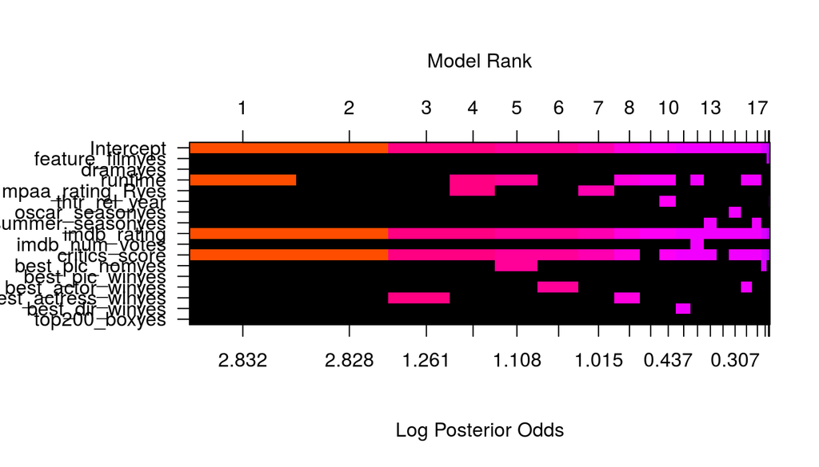

```r
image(movies_bayesian, rotate=FALSE)
```

Figure 4. We can see that most valuable predictors are `imdb_rating`, `critics_score` and to a lesser extent `runtime`. The fact the IMDB rating (movie rating from IMDB website) and critics score (critics score from RT website) are almost always included in the model is not really surprising as strong relationship with audience score is expected.

Now let’s create a new model including only valuable predictors. We don’t need to use MCMC since there the number of combinations is only $2^{3}$.

```r
bayesian_movies_reduced = bas.lm(audience_score ~ imdb_rating + critics_score + runtime, data = movies, prior = "BIC", modelprior = uniform())
coefficients(bayesian_movies_reduced)
```

```
##
##  Marginal Posterior Summaries of Coefficients:
##
##  Using  BMA
##
##  Based on the top  8 models
##                post mean  post SD   post p(B != 0)
## Intercept      62.21002    0.40900   1.00000
## imdb_rating    14.89079    0.72722   1.00000
## critics_score   0.07129    0.02889   0.93233
## runtime        -0.03138    0.03333   0.53966
```

Posterior mean and posterior standard deviation are self explanatory. Post P(B != 0) column provides probability that the coefficient is not 0.

Now let’s select the best estimator (bayesian model averaging[BMA], best predictive model[BPM], highest probability model[HPM], median probability model[MPM]) for our model using cross validation.

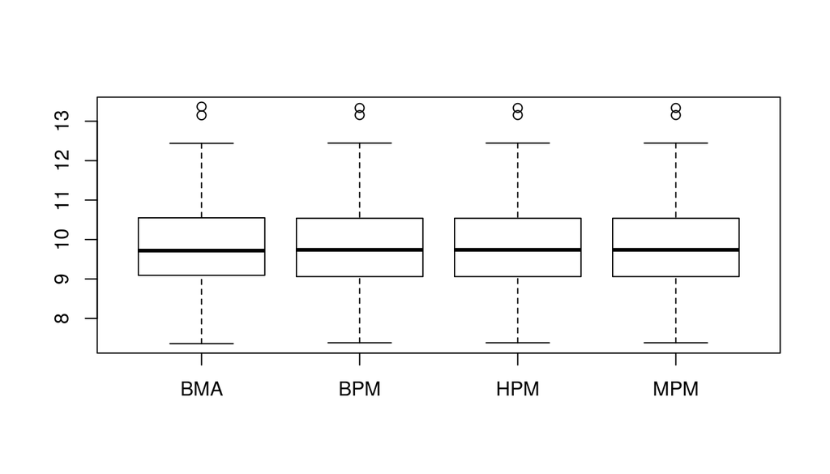

```r
n = nrow(movies)
#cross validation
n_cv = 100
ape = matrix(NA, ncol=4, nrow=n_cv)
colnames(ape) = c("BMA", "BPM", "HPM", "MPM")

for (i in 1:n_cv) {
  train = sample(1:n, size=round(.90*n), replace=FALSE)
  lmovies_train = movies[train,]
  lmovies_test = movies[-train,]

  bayesian_movies_reduced = bas.lm(audience_score ~ imdb_rating + critics_score + runtime, data = movies, prior = "BIC", modelprior = uniform())

  yhat_bma = predict(bayesian_movies_reduced, lmovies_test, estimator="BMA")$fit
  yhat_hpm = predict(bayesian_movies_reduced, lmovies_test, estimator="HPM")$fit
  yhat_mpm = predict(bayesian_movies_reduced, lmovies_test, estimator="MPM")$fit
  yhat_bpm = predict(bayesian_movies_reduced, lmovies_test, estimator="BPM")$fit
  ape[i, "BMA"] = cv.summary.bas(yhat_bma, lmovies_test$audience_score)
  ape[i, "BPM"] = cv.summary.bas(yhat_bpm, lmovies_test$audience_score)
  ape[i, "HPM"] = cv.summary.bas(yhat_hpm, lmovies_test$audience_score)
  ape[i, "MPM"] = cv.summary.bas(yhat_mpm, lmovies_test$audience_score)
}
boxplot(ape)
```

```r
apply(ape, 2, mean)
```

```
##      BMA      BPM      HPM      MPM
## 9.829203 9.815692 9.815692 9.815692
```

## Part 5: Prediction

Let’s pick three movies. One with average rating, one with high rating and one which scored bad.

1. Get Out - 99% critics rating, 87% audience rating, 7.7 IMDB rating.
2. Sweet Virginia - 77% critics rating, 64% audience rating, 6.3 IMBD rating.
3. Just Getting Started - 5% critics rating, 17% audience rating, 3.9 IMDB rating.

```r
get_out = data.frame(imdb_rating = 7.7, critics_score = 99, runtime = 104)
sweet_virginia = data.frame(imdb_rating = 6.3, critics_score = 77, runtime = 93)
just_getting_started = data.frame(imdb_rating = 3.9, critics_score = 5, runtime = 91)
#prediction Get Out
get_out_predict <- predict(bayesian_movies_reduced, newdata = get_out, estimator = 'BPM', se.fit = TRUE)
ci_get_out = confint(get_out_predict, estimator="BPM")
#prediction Sweet Virginia
sweet_virginia_predict <- predict(bayesian_movies_reduced, newdata = sweet_virginia, estimator = 'BPM', se.fit = TRUE)
ci_sweet_virginia = confint(sweet_virginia_predict, estimator="BPM")
#prediction Jsut Getting Started
jgs_predict <- predict(bayesian_movies_reduced, newdata = just_getting_started, estimator = 'BPM', se.fit = TRUE)
ci_jgs = confint(jgs_predict, estimator="BPM")
```

Now lets examine the results.

Prediction interval and prediction for **Get Out** movie is:

```r
ci_get_out[1,]
```

```
##      2.5%     97.5%      pred
##  63.09438 103.23846  83.16642
```

The real `audience_score` value is 87, which is pretty close.

Next is **Sweet Virginia**

```r
ci_sweet_virginia[1,]
```

```
##     2.5%    97.5%     pred
## 40.95952 81.08707 61.02329
```

The real rating of the movie is 64, which is slightly off but again pretty close.

And finally our low ranking movie **Just Getting Started**

```r
ci_jgs[1,]
```

```
##       2.5%      97.5%       pred
##  0.1245959 40.7467658 20.4356808
```

The model overestimated the rating by ~3 points. With real rating being equal to 17.

## Part 6: Conclusion

After the analysis I can conclude that most of the suggested variables are useless for `audience_score` prediction. In fact model utilizing only 3 variables, 2 of which are other ratings, is sufficient for predicting the response variable. However I think the finding it trivial, because ratings are expected to be highly corellated. In other words it is not really a surprise that movies which scored high on IMDB have higher `audience_score` on rotten tomatoes. With that being sad the model makes good predictions. The only unexpected variable which also affects the rating is `runtime`, however the probability that `runtime` coefficient is not zero is only 50%, with probabilities for other rating coefficients being close to 1.

It seems that identifying variables which are not trivial requires more sophisticated techniques, or they might not affect the rating at all.

## Part 7: References

I have borrowed code for estimator cross-validation from week 4 lab supplmentary materials. https://www.coursera.org/learn/bayesian/supplement/HJxzL/week-4-lab-supplement